# Red wine data exploration by Sonal Garg

This report explores a dataset of red wines and determines which chemical properties influence the quality of red wines.

```
## [1] 1599   13
```

```
## 'data.frame':    1599 obs. of  13 variables:
##  $ X                   : int  1 2 3 4 5 6 7 8 9 10 ...
##  $ fixed.acidity       : num  7.4 7.8 7.8 11.2 7.4 7.4 7.9 7.3 7.8 7.5 ...
##  $ volatile.acidity    : num  0.7 0.88 0.76 0.28 0.7 0.66 0.6 0.65 0.58 0.5 ...
##  $ citric.acid         : num  0 0 0.04 0.56 0 0 0.06 0 0.02 0.36 ...
##  $ residual.sugar      : num  1.9 2.6 2.3 1.9 1.9 1.8 1.6 1.2 2 6.1 ...
##  $ chlorides           : num  0.076 0.098 0.092 0.075 0.076 0.075 0.069 0.065 0.073 0.071 ...
##  $ free.sulfur.dioxide : num  11 25 15 17 11 13 15 15 9 17 ...
##  $ total.sulfur.dioxide: num  34 67 54 60 34 40 59 21 18 102 ...
##  $ density             : num  0.998 0.997 0.997 0.998 0.998 ...
##  $ pH                  : num  3.51 3.2 3.26 3.16 3.51 3.51 3.3 3.39 3.36 3.35 ...
##  $ sulphates           : num  0.56 0.68 0.65 0.58 0.56 0.56 0.46 0.47 0.57 0.8 ...
##  $ alcohol             : num  9.4 9.8 9.8 9.8 9.4 9.4 9.4 10 9.5 10.5 ...
##  $ quality             : int  5 5 5 6 5 5 5 7 7 5 ...
```

```
##        X          fixed.acidity   volatile.acidity  citric.acid
##  Min.   :   1.0   Min.   : 4.60   Min.   :0.1200   Min.   :0.000
##  1st Qu.: 400.5   1st Qu.: 7.10   1st Qu.:0.3900   1st Qu.:0.090
##  Median : 800.0   Median : 7.90   Median :0.5200   Median :0.260
##  Mean   : 800.0   Mean   : 8.32   Mean   :0.5278   Mean   :0.271
##  3rd Qu.:1199.5   3rd Qu.: 9.20   3rd Qu.:0.6400   3rd Qu.:0.420
##  Max.   :1599.0   Max.   :15.90   Max.   :1.5800   Max.   :1.000
##  residual.sugar     chlorides       free.sulfur.dioxide
##  Min.   : 0.900   Min.   :0.01200   Min.   : 1.00
##  1st Qu.: 1.900   1st Qu.:0.07000   1st Qu.: 7.00
##  Median : 2.200   Median :0.07900   Median :14.00
##  Mean   : 2.539   Mean   :0.08747   Mean   :15.87
##  3rd Qu.: 2.600   3rd Qu.:0.09000   3rd Qu.:21.00
##  Max.   :15.500   Max.   :0.61100   Max.   :72.00
##  total.sulfur.dioxide    density             pH          sulphates
##  Min.   :  6.00       Min.   :0.9901   Min.   :2.740   Min.   :0.3300
##  1st Qu.: 22.00       1st Qu.:0.9956   1st Qu.:3.210   1st Qu.:0.5500
##  Median : 38.00       Median :0.9968   Median :3.310   Median :0.6200
##  Mean   : 46.47       Mean   :0.9967   Mean   :3.311   Mean   :0.6581
##  3rd Qu.: 62.00       3rd Qu.:0.9978   3rd Qu.:3.400   3rd Qu.:0.7300
##  Max.   :289.00       Max.   :1.0037   Max.   :4.010   Max.   :2.0000
##     alcohol      quality
##  Min.   : 8.40   3: 10
##  1st Qu.: 9.50   4: 53
##  Median :10.20   5:681
##  Mean   :10.42   6:638
##  3rd Qu.:11.10   7:199
##  Max.   :14.90   8: 18
```

Our dataset consists of 13 variables with 1599 observations of red wines.

# Univariate Plots Section

## Including Plots

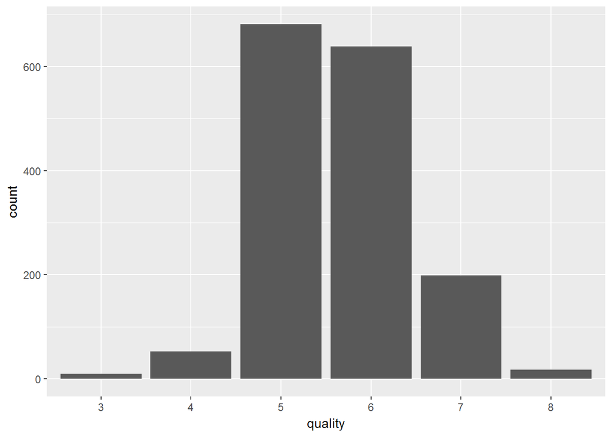

```
## [1] 0.8248906
```

The plot of quality of wines shows that 82.4% of the wines in our dataset are wines of average quality (between 5-6). This means there are only a few wines which are of poor or excellent quality.

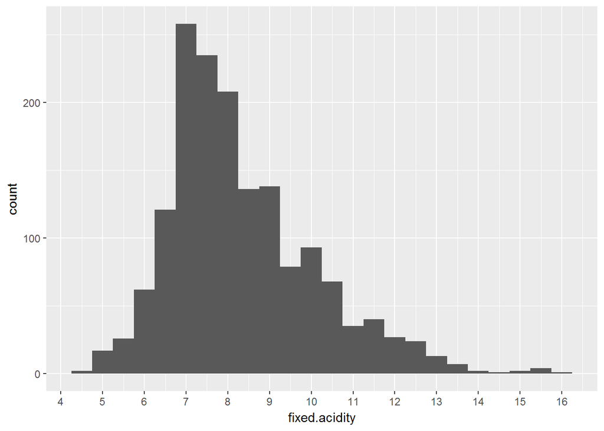

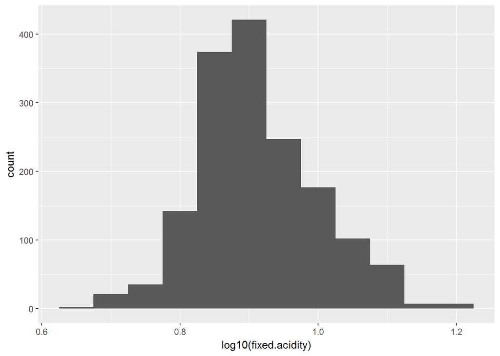

```
##    Min. 1st Qu.  Median    Mean 3rd Qu.    Max.
##    4.60    7.10    7.90    8.32    9.20   15.90
```

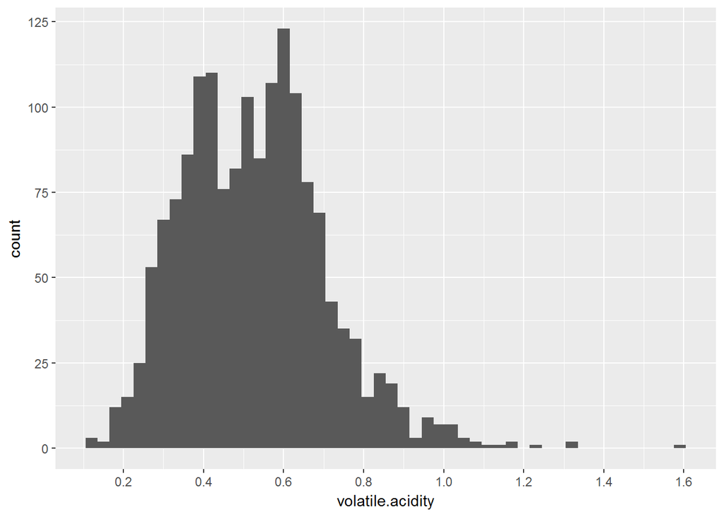

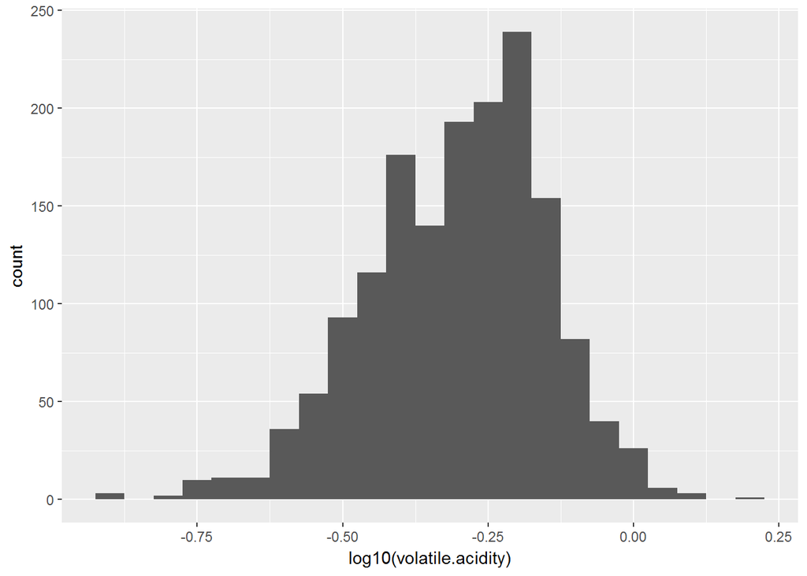

```
##    Min. 1st Qu.  Median    Mean 3rd Qu.    Max.
##  0.1200  0.3900  0.5200  0.5278  0.6400  1.5800
```

Volatile acidity lies between the range of 0.2 and 0.9. There are certain outliers around the value of 1.6. The log plot of volatile acidity seems to be more binomially distributed.

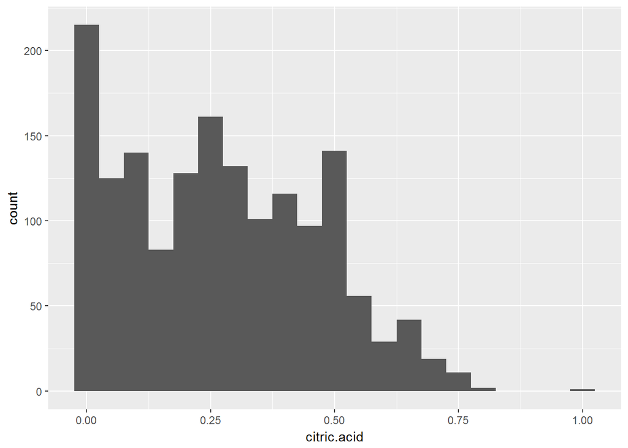

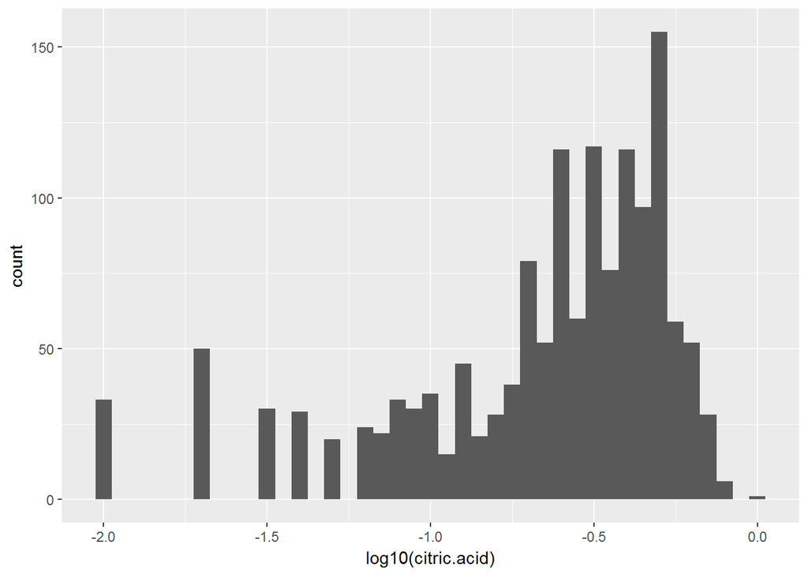

```
##    Min. 1st Qu.  Median    Mean 3rd Qu.    Max.
##   0.000   0.090   0.260   0.271   0.420   1.000
```

Citric acid seems to have a long tail distribution. Interestingly, plotting the log value of citric acid, makes it long left tail distribution. There are certain outliers at value of 1.00.

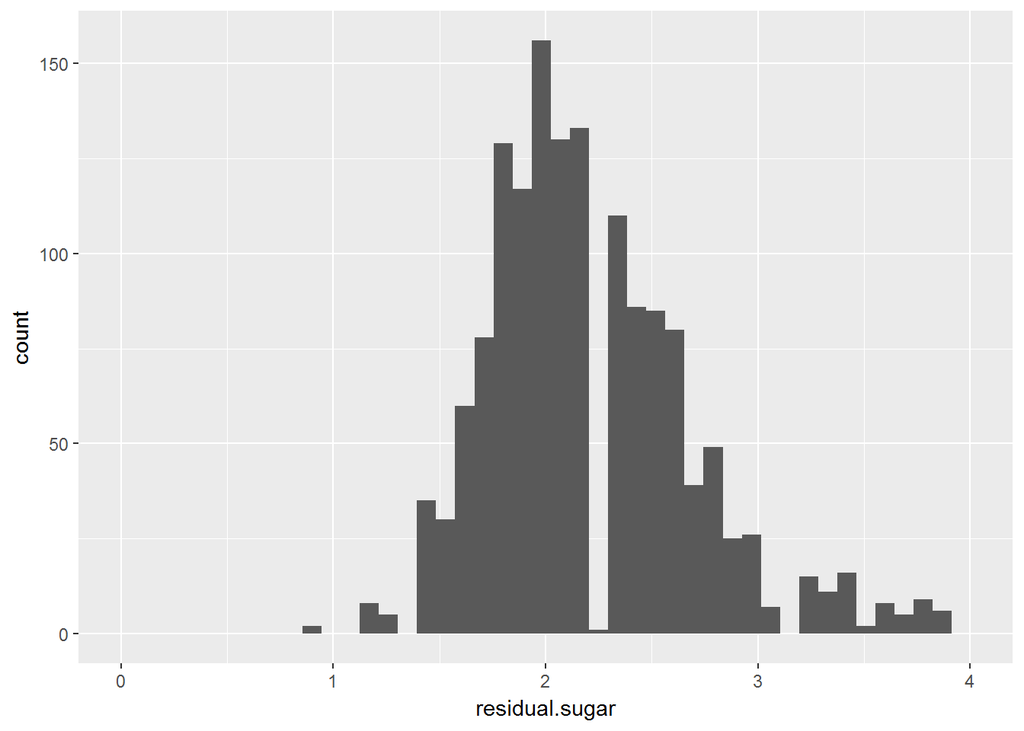

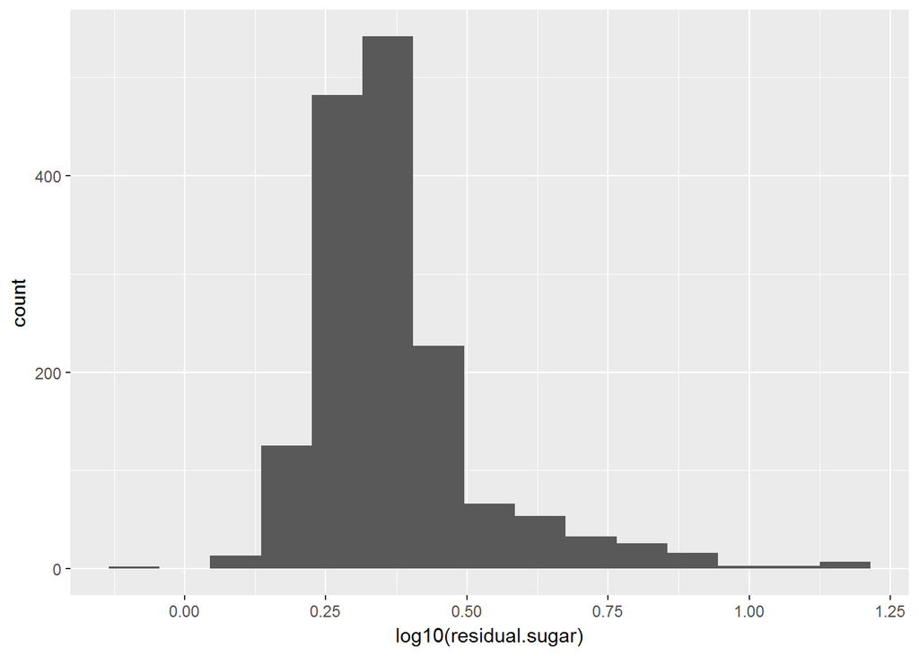

```
##    Min. 1st Qu.  Median    Mean 3rd Qu.    Max.
##   0.900   1.900   2.200   2.539   2.600  15.500
```

Residual sugar seems to have a very interesting plot. Most of the values are centered between 1 and 4, highest being 2.However, there are many outliers going as far as 15.5. Plotting a log plot shows similar findings but looks more normally distributed.

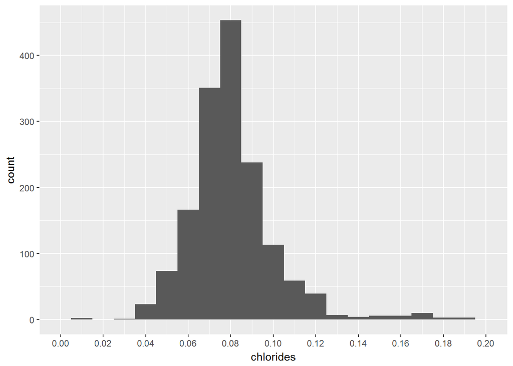

```
##    Min. 1st Qu.  Median    Mean 3rd Qu.    Max.
## 0.01200 0.07000 0.07900 0.08747 0.09000 0.61100
```

Chlorides seem to have a plot similar to residual sugar. Most of the values are centered on its median value of 0.079 and there are many outliers present going as far as 0.611. The plot around the median value seems to be normally distributed.

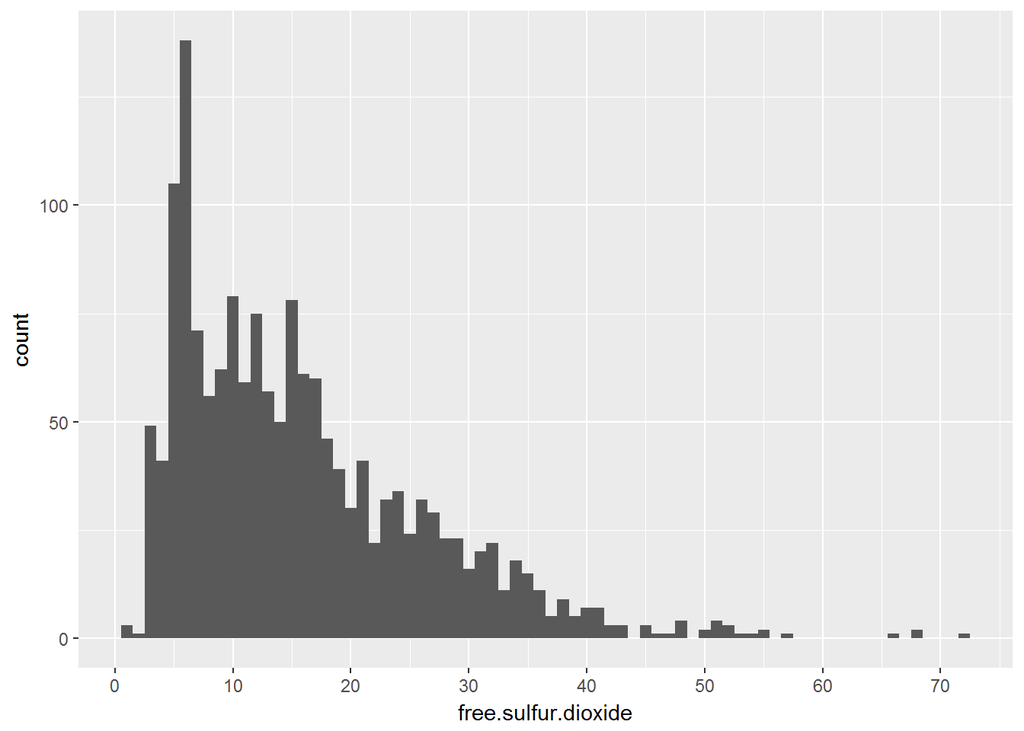

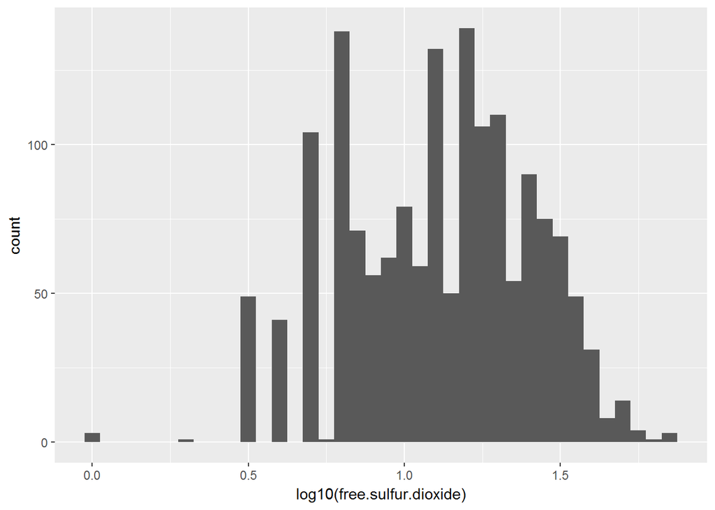

```
##    Min. 1st Qu.  Median    Mean 3rd Qu.    Max.
##    1.00    7.00   14.00   15.87   21.00   72.00
```

Free sulfur dioxide seems to have a long right tail distribution. There are some outliers around the values of 65 and 72.This feature has one of the higher Inter quantile ranges.

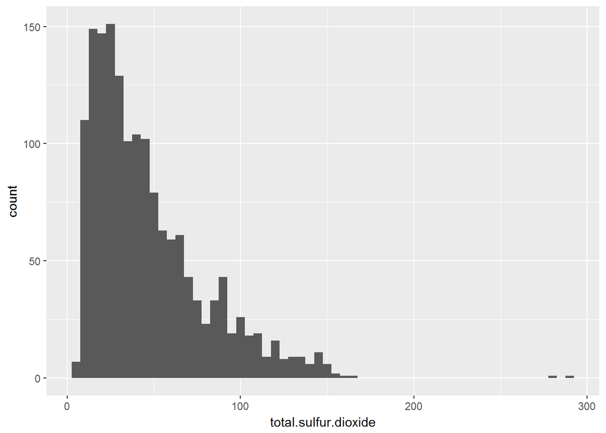

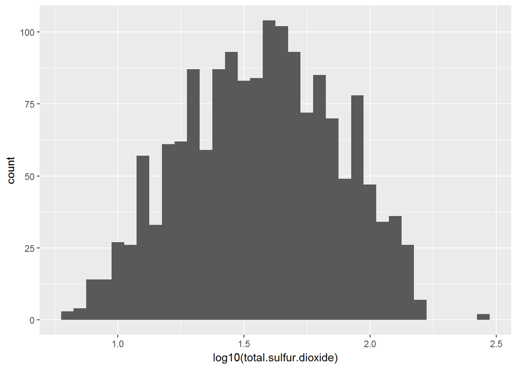

```
##    Min. 1st Qu.  Median    Mean 3rd Qu.    Max.
##    6.00   22.00   38.00   46.47   62.00  289.00
```

Total sulfur dioxide similar to above, seems to have a long right tail distribution.The log plot shows more binomial distribution.Again, this feature has one of the higher Inter quantile ranges.

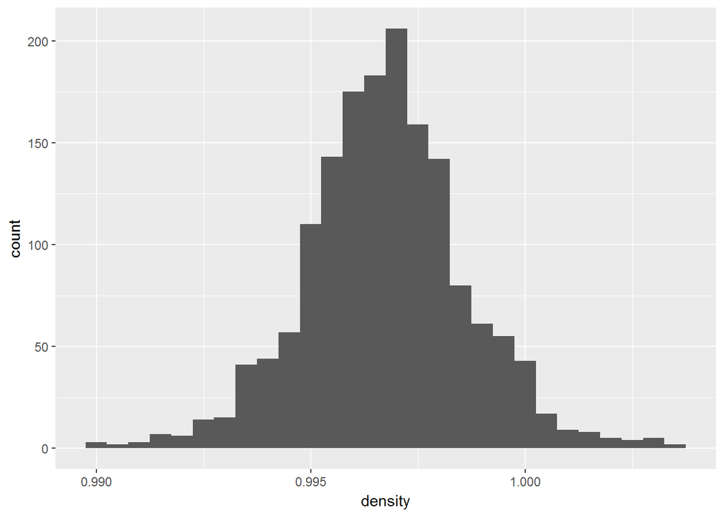

Density seems to be the most normally distributed feature as of now. There are a few outliers, however most of the values lie between 0.995 and 1.

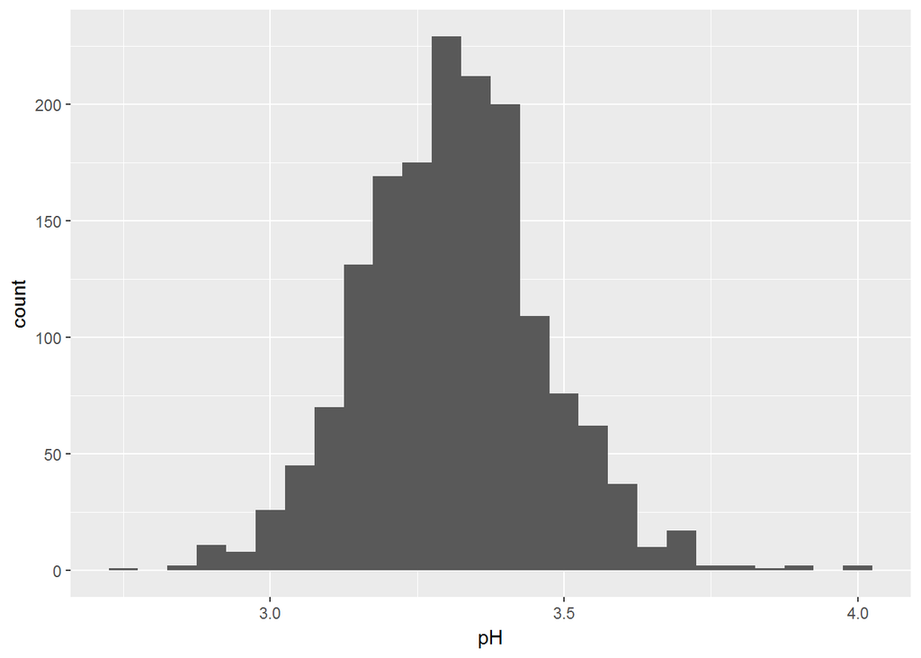

```
##    Min. 1st Qu.  Median    Mean 3rd Qu.    Max.
##   2.740   3.210   3.310   3.311   3.400   4.010
```

pH also similarly to density is normally distributed around a median value of 3.3 between the range of 3 and 3.5.There are a few outliers around a value of 4. For reference, pH value of 0 shows acidic nature and pH value of 14 shows basic nature.

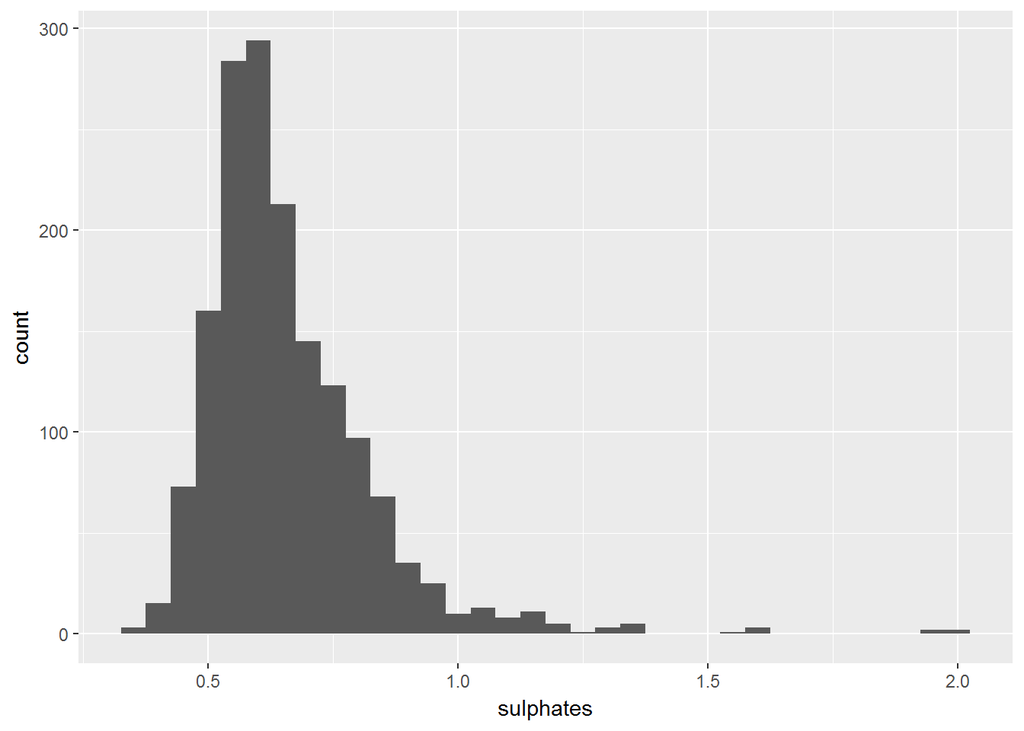

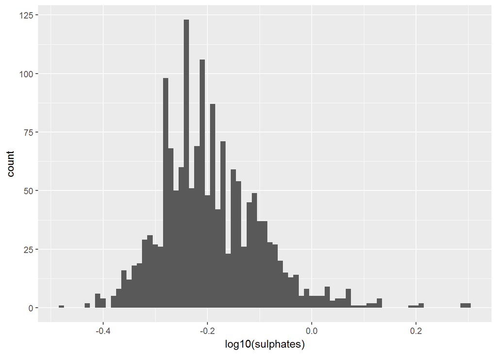

```
##    Min. 1st Qu.  Median    Mean 3rd Qu.    Max.
##  0.3300  0.5500  0.6200  0.6581  0.7300  2.0000
```

Sulphates again seem to be normally distributed with majority of the values lyin in the range of 0.5 and 1.0. There are a few outliers around the value of 1.5 and 2.0. The log plot of sulphates shows more normal distribution.

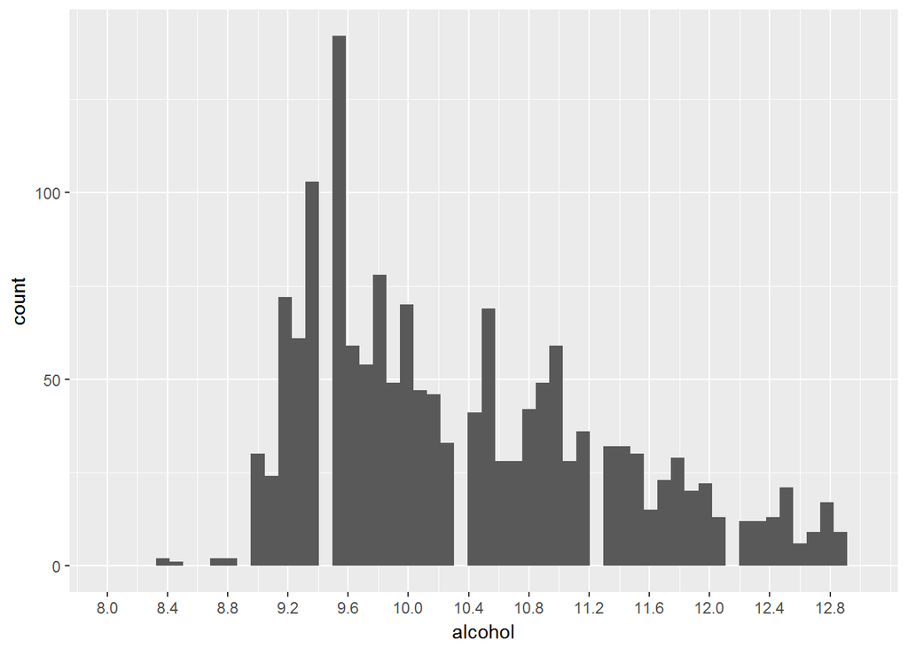

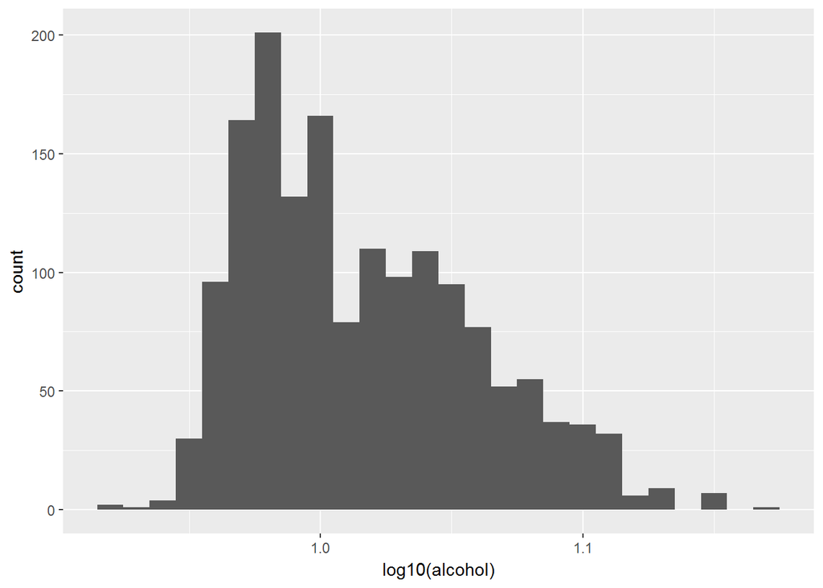

```
##    Min. 1st Qu.  Median    Mean 3rd Qu.    Max.
##    8.40    9.50   10.20   10.42   11.10   14.90
```

Alcohol has an interesting plot. Outliers are not much and the majority values range from 8.9 to 12.8 with a median value of 10.20.The log plot is also very similar.

# Univariate Analysis

### What is the structure of your dataset?

The dataset includes data of 1599 wines and 12 features(total 13 variables).We are interested in determining the chemical properties which determine the ‘quality’ of the wines.

On analysis I found that most of wines in our dataset are of average quality. There are only a few wines which are of very poor (0) or very excellent (10) quality.

### What is/are the main feature(s) of interest in your dataset?

As per the initial investigation, the main features in the data set for determining the quality of wines seems to be alcohol content,pH,density, acidity and sulphates.

### What other features in the dataset do you think will help support your investigation into your feature(s) of interest?

I believe, suphur dioxide (both free and total) can be helpful in the analysis.

### Did you create any new variables from existing variables in the dataset?

No, I did not create any new variable in the data set.

### Of the features you investigated, were there any unusual distributions? Did you perform any operations on the data to tidy, adjust, or change the form of the data? If so, why did you do this?

No operations were performed on the given data set. Some unusual outliers were found in features like fixed acidity,voltaile acidity, suphur dioxide(both free and total)

# Bivariate Plots Section

## Including Plots

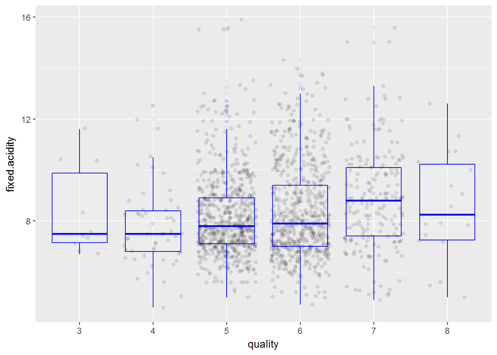

```
##
##  Pearson's product-moment correlation
##
## data:  pd$fixed.acidity and as.numeric(levels(pd$quality))[pd$quality]
## t = 4.996, df = 1597, p-value = 6.496e-07
## alternative hypothesis: true correlation is not equal to 0
## 95 percent confidence interval:
##  0.07548957 0.17202667
## sample estimates:
##       cor
## 0.1240516
```

```
##    Min. 1st Qu.  Median    Mean 3rd Qu.    Max.
##    4.60    7.10    7.90    8.32    9.20   15.90
```

Fixed acidity and quality seems to have a small positive correlation.However, the mean and values remain almost unchanged as the quality of wines increases. One thing to be noted is that there are no outliers for wines of poor and good quality here.

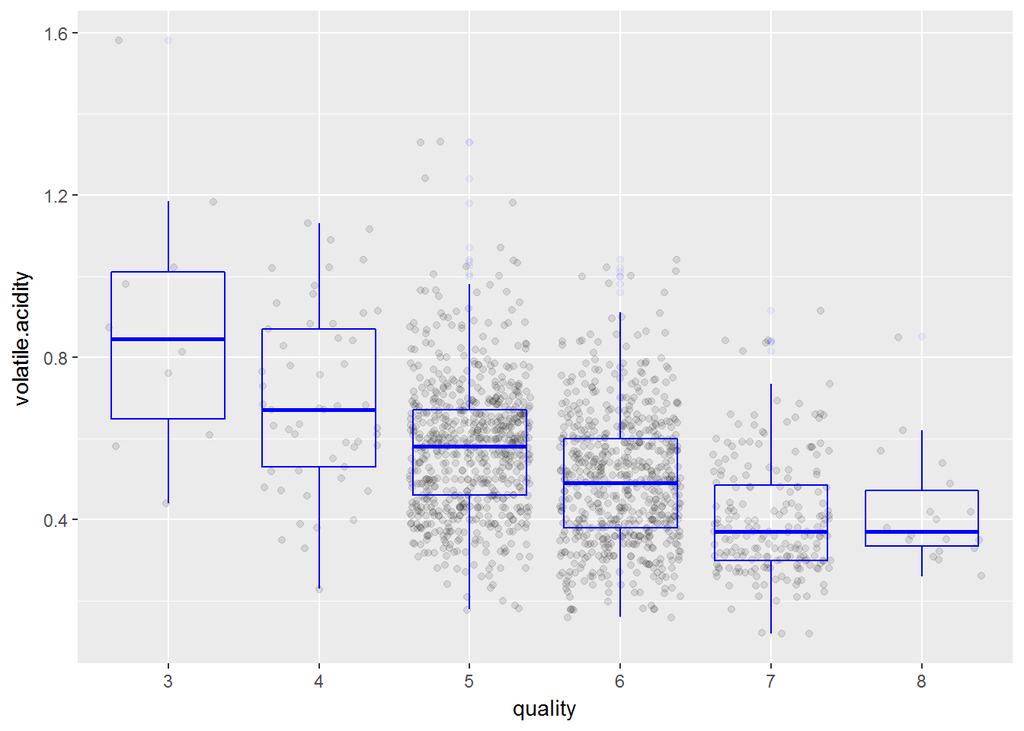

```
##
##  Pearson's product-moment correlation
##
## data:  pd$volatile.acidity and as.numeric(levels(pd$quality))[pd$quality]
## t = -16.954, df = 1597, p-value < 2.2e-16
## alternative hypothesis: true correlation is not equal to 0
## 95 percent confidence interval:
##  -0.4313210 -0.3482032
## sample estimates:
##        cor
## -0.3905578
```

```
##    Min. 1st Qu.  Median    Mean 3rd Qu.    Max.
##  0.1200  0.3900  0.5200  0.5278  0.6400  1.5800
```

Volatile acidity and quality have a negative correlation. As the quality of wines increases, value of volatile acidity is decreasing. This means better wines have lesser volatile acidity. Better wines have a volatile acidity content lesser than there mean/median values.

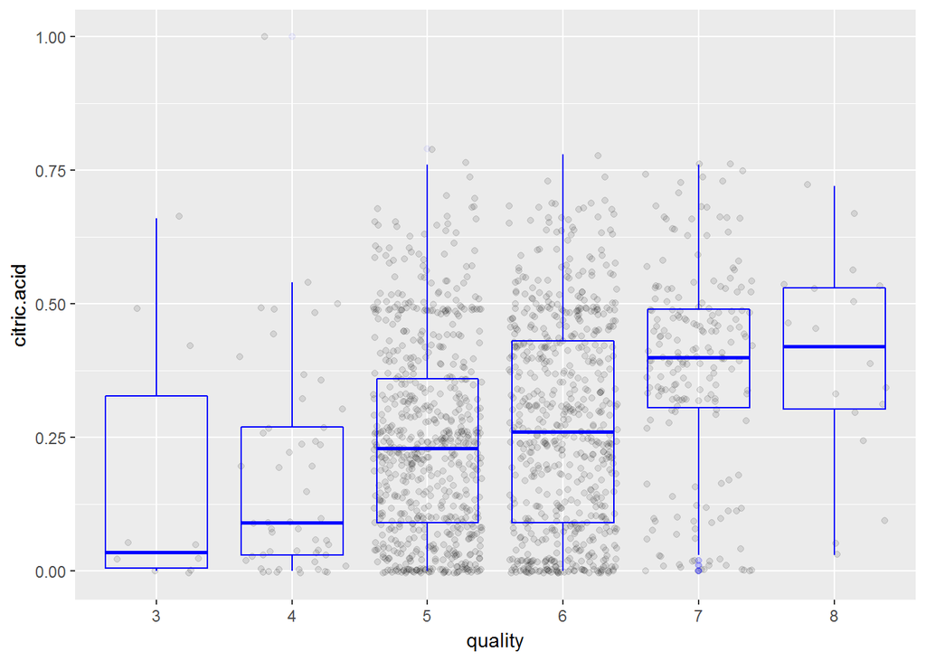

```
##
##  Pearson's product-moment correlation
##
## data:  pd$citric.acid and as.numeric(levels(pd$quality))[pd$quality]
## t = 9.2875, df = 1597, p-value < 2.2e-16
## alternative hypothesis: true correlation is not equal to 0
## 95 percent confidence interval:
##  0.1793415 0.2723711
## sample estimates:
##       cor
## 0.2263725
```

```
##    Min. 1st Qu.  Median    Mean 3rd Qu.    Max.
##   0.000   0.090   0.260   0.271   0.420   1.000
```

Citric acid has a positive and stronger correlation with quality. Better wines have higher citric acid content. Also, the average wines have a citric acid value near to there mean/median value. There is an outlier with very low value for a wine of quality 7.

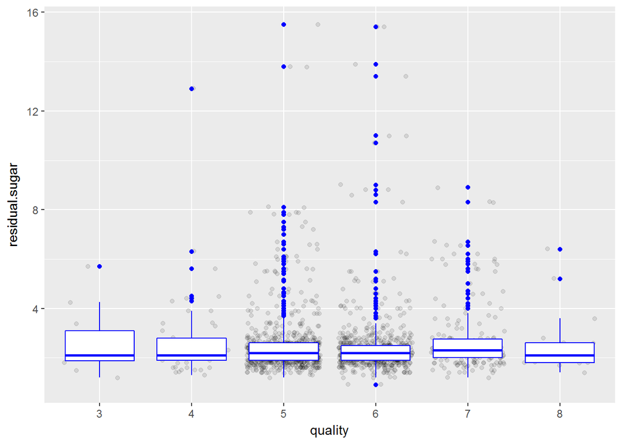

```
##
##  Pearson's product-moment correlation
##
## data:  pd$residual.sugar and as.numeric(levels(pd$quality))[pd$quality]
## t = 0.5488, df = 1597, p-value = 0.5832
## alternative hypothesis: true correlation is not equal to 0
## 95 percent confidence interval:
##  -0.03531327  0.06271056
## sample estimates:
##        cor
## 0.01373164
```

```
##    Min. 1st Qu.  Median    Mean 3rd Qu.    Max.
##   0.900   1.900   2.200   2.539   2.600  15.500
```

Residual sugar does not seem to have much impact on the quality of wines. The values remain almost similar for each quality of wine. The correlation coefficient is also very small. As analyzed earlier, there are many outliers in this case, more for average quality wines.

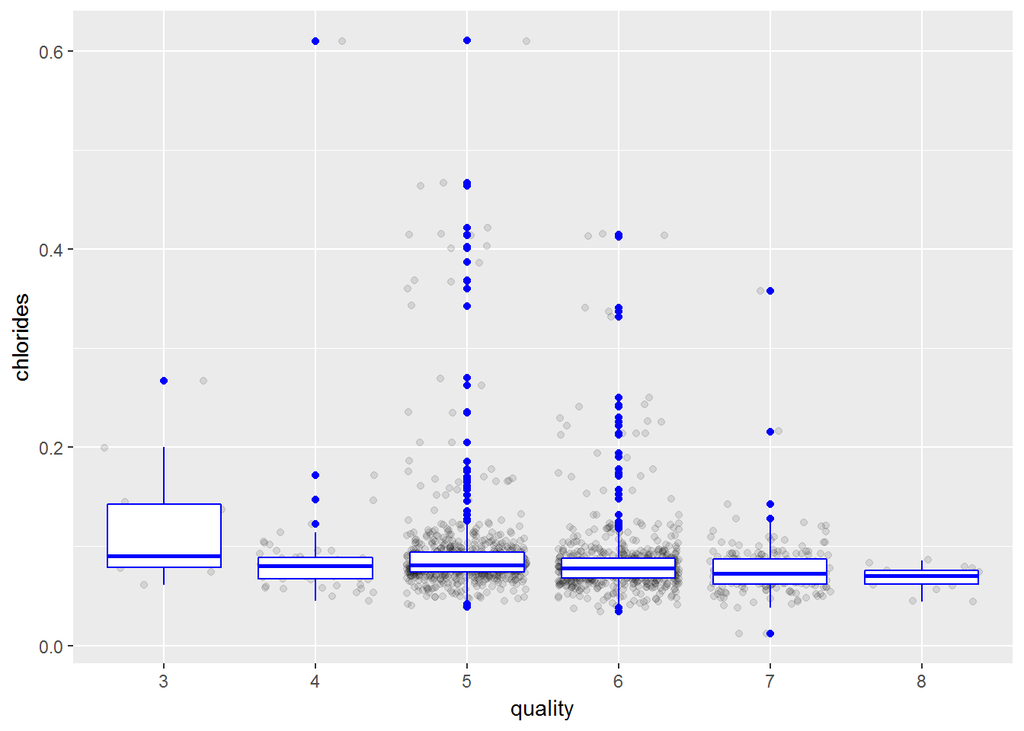

```
##
##  Pearson's product-moment correlation
##
## data:  pd$chlorides and as.numeric(levels(pd$quality))[pd$quality]
## t = -5.1948, df = 1597, p-value = 2.313e-07
## alternative hypothesis: true correlation is not equal to 0
## 95 percent confidence interval:
##  -0.17681041 -0.08039344
## sample estimates:
##        cor
## -0.1289066
```

```
##    Min. 1st Qu.  Median    Mean 3rd Qu.    Max.
## 0.01200 0.07000 0.07900 0.08747 0.09000 0.61100
```

Chlorides and quality again do not seem to be much impactful. The correlation coefficient is also a small negative value. All the wines seem to have a value nearby the median/mean values. But we can assume, better wines have less chlorides.

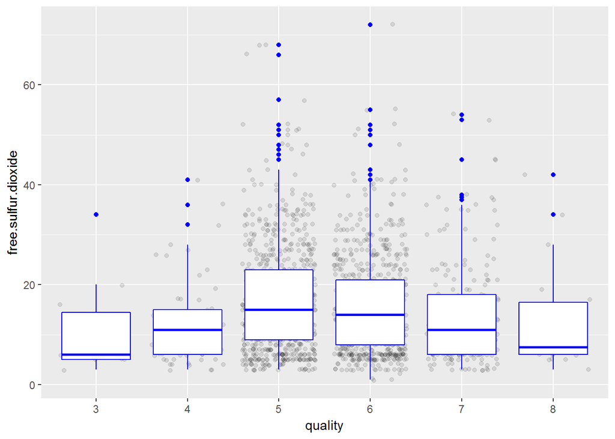

```
##
##  Pearson's product-moment correlation
##
## data:  pd$free.sulfur.dioxide and as.numeric(levels(pd$quality))[pd$quality]
## t = -2.0269, df = 1597, p-value = 0.04283
## alternative hypothesis: true correlation is not equal to 0
## 95 percent confidence interval:
##  -0.099430290 -0.001638987
## sample estimates:
##         cor
## -0.05065606
```

```
##    Min. 1st Qu.  Median    Mean 3rd Qu.    Max.
##    1.00    7.00   14.00   15.87   21.00   72.00
```

Free sulfur dioxide has an interesting relation with quality. Lower quality wines have lesser value and as quality increases, the value of free sulfur dioxide increases and then decreases for extremely good quality wines. Conclusively, lesser concentration of sulfur dioxide results in poor wines and higher concentration of the same results in only average wines.

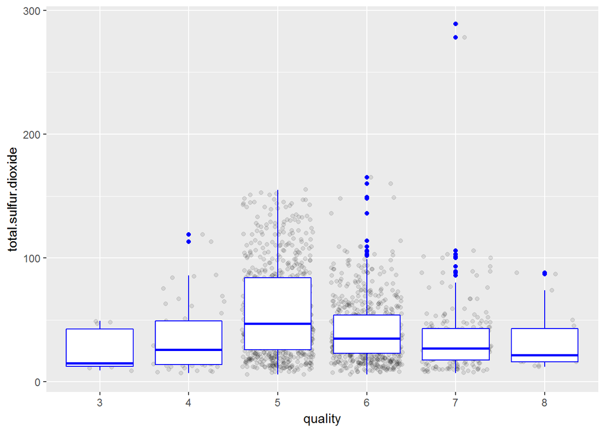

```
##
##  Pearson's product-moment correlation
##
## data:  pd$total.sulfur.dioxide and as.numeric(levels(pd$quality))[pd$quality]
## t = -7.5271, df = 1597, p-value = 8.622e-14
## alternative hypothesis: true correlation is not equal to 0
## 95 percent confidence interval:
##  -0.2320162 -0.1373252
## sample estimates:
##        cor
## -0.1851003
```

```
##    Min. 1st Qu.  Median    Mean 3rd Qu.    Max.
##    6.00   22.00   38.00   46.47   62.00  289.00
```

Total sulfur dioxide seems to have a similar relationship with quality as free sulfur dioxide. Average quality wines have higher concentration of total sulfur dioxide and poor or better quality wines have lesser concentration.

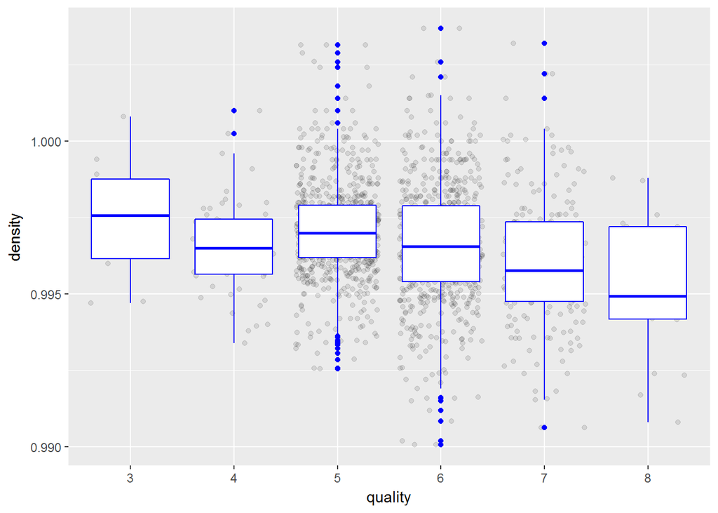

```
##
##  Pearson's product-moment correlation
##
## data:  pd$density and as.numeric(levels(pd$quality))[pd$quality]
## t = -7.0997, df = 1597, p-value = 1.875e-12
## alternative hypothesis: true correlation is not equal to 0
## 95 percent confidence interval:
##  -0.2220365 -0.1269870
## sample estimates:
##        cor
## -0.1749192
```

```
##    Min. 1st Qu.  Median    Mean 3rd Qu.    Max.
##  0.9901  0.9956  0.9968  0.9967  0.9978  1.0037
```

Density does not seem to have a clear relationship with quality. We can assume though that better wines have lesser density.There are no outliers for poor and good quality of wines.

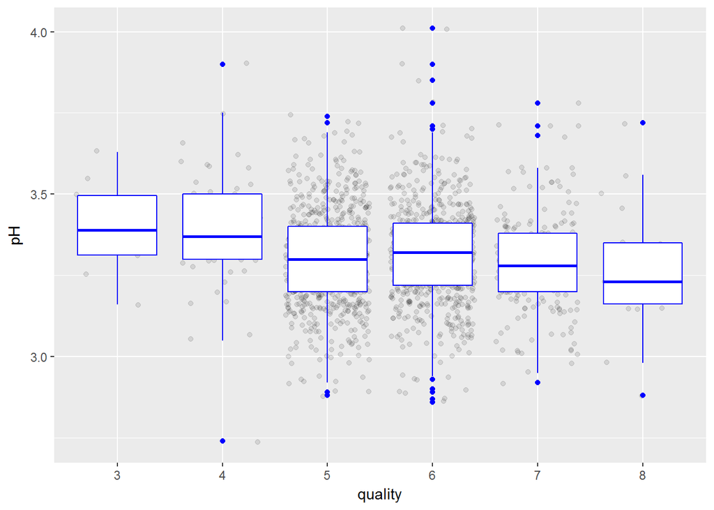

```
##
##  Pearson's product-moment correlation
##
## data:  pd$pH and as.numeric(levels(pd$quality))[pd$quality]
## t = -2.3109, df = 1597, p-value = 0.02096
## alternative hypothesis: true correlation is not equal to 0
## 95 percent confidence interval:
##  -0.106451268 -0.008734972
## sample estimates:
##         cor
## -0.05773139
```

```
##    Min. 1st Qu.  Median    Mean 3rd Qu.    Max.
##   2.740   3.210   3.310   3.311   3.400   4.010
```

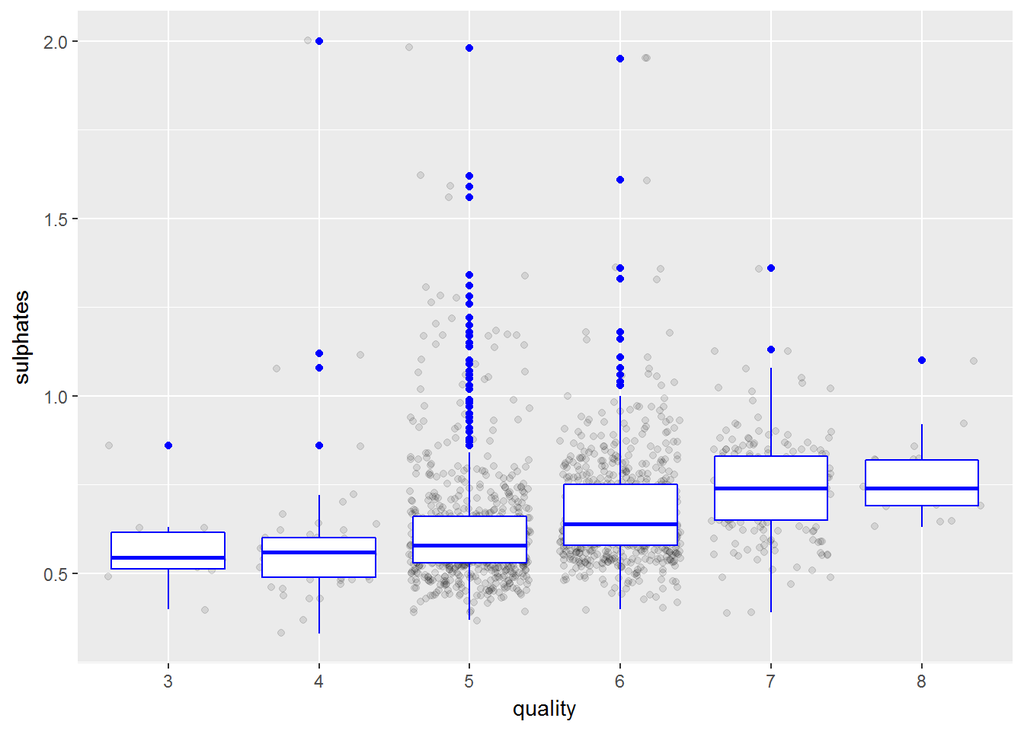

```
##
##  Pearson's product-moment correlation
##
## data:  pd$sulphates and as.numeric(levels(pd$quality))[pd$quality]
## t = 10.38, df = 1597, p-value < 2.2e-16
## alternative hypothesis: true correlation is not equal to 0
## 95 percent confidence interval:
##  0.2049011 0.2967610
## sample estimates:
##       cor
## 0.2513971
```

```
##    Min. 1st Qu.  Median    Mean 3rd Qu.    Max.
##  0.3300  0.5500  0.6200  0.6581  0.7300  2.0000
```

Sulphates and quality have a stronger positive correlation. Better wines have higher sulphates concentration. Better quality wines have there sulphates value higher than the mean/median value.

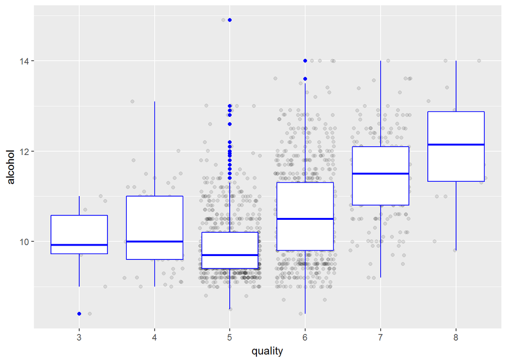

```
##
##  Pearson's product-moment correlation
##
## data:  pd$alcohol and as.numeric(levels(pd$quality))[pd$quality]
## t = 21.639, df = 1597, p-value < 2.2e-16
## alternative hypothesis: true correlation is not equal to 0
## 95 percent confidence interval:
##  0.4373540 0.5132081
## sample estimates:
##       cor
## 0.4761663
```

```
##    Min. 1st Qu.  Median    Mean 3rd Qu.    Max.
##    8.40    9.50   10.20   10.42   11.10   14.90
```

Alcohol clearly has the strongest correlation with quality and this correlation is positive. Better wines simply have higher alcohol content. Wines of better quality have alcohol content much greater than the mean/median value. Also, there are no outliers present for better quality wines.

Below is a correlation matrix for our dataset.

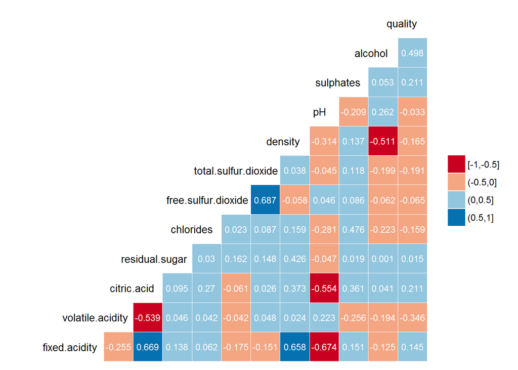

# Bivariate Analysis

### Talk about some of the relationships you observed in this part of the investigation. How did the feature(s) of interest vary with other features in the dataset?

I derived from the analysis that following factors seem to be the most determining factors for quality:

- alcohol
- volatile acidity
- sulphates
- citric acid
- sulphur dioxide(both free and total)
- density
- pH

### Did you observe any interesting relationships between the other features (not the main feature(s) of interest)?

Yes, there was a strange relationship between pH,quality and other acidity measuring features.

Now, both citric acid and fixed acidity have positive correlation with quality. This also means, better quality wines will have higher acidic coefficient. This seems to be a contradiction.

Now, as derived from the last plot, pH and citric acid as well as pH and fixed acidity have strong negative correlation. This means wines with lower pH will have higher acidity. This seems to be very confusing to me. I think this is a paradox.

### What was the strongest relationship you found?

Alcohol seems to have the strongest relationship with quality. Better quality wines have higher alcohol content. After that, I feel volatile acidity can be impactful.